# Project: Investigate a Dataset - [Database_TMDb_movie_data]

- Introduction
- Data Wrangling
- Exploratory Data Analysis
- Conclusions

## Introduction

> This project is an investigation on the movie data from TMDb. The aim is to investigate the dataset, carry out an analysis, and make inferences from the analysis done.

> The original dataset has 21 columns [or variables] & 10866 rows [or entries]. The columns are:
> - id - The movie id.
> - imdb_id - movie id on IMDb.
> - popularity - This represents the popularity.
> - budget - This represents the budget that was used to produced a movie in dollars.
> - revenue - This represents the revenue that made from a movie in dollars.
> - original_title - This represents the title of a movie.
> - cast - This represents the cast of actors/actresses that starred in a movie.
> - homepage - This represents the website of the movie.
> - director - This represents the director that directed the movie
> - tagline - This represents the tagline associated to a movie.
> - keywords - This represents the keywords associated to a movie.
> - overview - This represents the synopsis of a movie.
> - runtime - This represents the runtime of the movie.
> - genres - This represents the genre of the movie.
> - production_companies - This represents companies that produced the movies.
> - release_date - This represents the date the movies was released.
> - vote_count - This represents the number of the audience that rated a movie.
> - vote_average - This represents the average rating of a movie.
> - release_year - This represents the year a movie was released.
> - budget_adj - This isn't very clear, but it is similar to the 'budget' column.
> - revenue_adj - This isn't very clear, but it is similar to the 'revenue' column.

> An intial **eight (8)** research questions will be asked to test the relationship between the different variables. These questions are:
> 1. Which movies are the most popular?
> 2. Which directors are the most popular?
> 3. Which directors feature most in the data?
> 4. Which movies made the most revenue?
> 5. Which movies made the most profit?
> 6. Which year produced the most movies?
> 7. Does runtime affect ratings?
> 8. Does runtime affect popularity?

```python
# Import the necessary libraries

import pandas as pd
import numpy as np
import seaborn as sns
import matplotlib.pyplot as plt
%matplotlib inline
```

```python
# Upgrade pandas to use dataframe.explode() function.
#!pip install --upgrade pandas==0.25.0
```

## Data Wrangling

```python
# Load data
df = pd.read_csv('tmdb-movies.csv')
df.head()
```

|  | id | imdb_id | popularity | budget | revenue | original_title | cast | homepage | director | tagline | ... | overview | runtime | genres | production_companies | release_date | vote_count | vote_average | release_year | budget_adj | revenue_adj |
| --- | --- | --- | --- | --- | --- | --- | --- | --- | --- | --- | --- | --- | --- | --- | --- | --- | --- | --- | --- | --- | --- |
| 0 | 135397 | tt0369610 | 32.985763 | 150000000 | 1513528810 | Jurassic World | Chris Pratt\|Bryce Dallas Howard\|Irrfan Khan\|Vi... | http://www.jurassicworld.com/ | Colin Trevorrow | The park is open. | ... | Twenty-two years after the events of Jurassic ... | 124 | Action\|Adventure\|Science Fiction\|Thriller | Universal Studios\|Amblin Entertainment\|Legenda... | 6/9/15 | 5562 | 6.5 | 2015 | 1.379999e+08 | 1.392446e+09 |
| 1 | 76341 | tt1392190 | 28.419936 | 150000000 | 378436354 | Mad Max: Fury Road | Tom Hardy\|Charlize Theron\|Hugh Keays-Byrne\|Nic... | http://www.madmaxmovie.com/ | George Miller | What a Lovely Day. | ... | An apocalyptic story set in the furthest reach... | 120 | Action\|Adventure\|Science Fiction\|Thriller | Village Roadshow Pictures\|Kennedy Miller Produ... | 5/13/15 | 6185 | 7.1 | 2015 | 1.379999e+08 | 3.481613e+08 |
| 2 | 262500 | tt2908446 | 13.112507 | 110000000 | 295238201 | Insurgent | Shailene Woodley\|Theo James\|Kate Winslet\|Ansel... | http://www.thedivergentseries.movie/#insurgent | Robert Schwentke | One Choice Can Destroy You | ... | Beatrice Prior must confront her inner demons ... | 119 | Adventure\|Science Fiction\|Thriller | Summit Entertainment\|Mandeville Films\|Red Wago... | 3/18/15 | 2480 | 6.3 | 2015 | 1.012000e+08 | 2.716190e+08 |
| 3 | 140607 | tt2488496 | 11.173104 | 200000000 | 2068178225 | Star Wars: The Force Awakens | Harrison Ford\|Mark Hamill\|Carrie Fisher\|Adam D... | http://www.starwars.com/films/star-wars-episod... | J.J. Abrams | Every generation has a story. | ... | Thirty years after defeating the Galactic Empi... | 136 | Action\|Adventure\|Science Fiction\|Fantasy | Lucasfilm\|Truenorth Productions\|Bad Robot | 12/15/15 | 5292 | 7.5 | 2015 | 1.839999e+08 | 1.902723e+09 |
| 4 | 168259 | tt2820852 | 9.335014 | 190000000 | 1506249360 | Furious 7 | Vin Diesel\|Paul Walker\|Jason Statham\|Michelle ... | http://www.furious7.com/ | James Wan | Vengeance Hits Home | ... | Deckard Shaw seeks revenge against Dominic Tor... | 137 | Action\|Crime\|Thriller | Universal Pictures\|Original Film\|Media Rights ... | 4/1/15 | 2947 | 7.3 | 2015 | 1.747999e+08 | 1.385749e+09 |

5 rows × 21 columns

```python
#Make a copy of the dataset
df_movie = df.copy()
```

```python
#Check the shape of the dataset
df_movie.shape
```

```
(10866, 21)
```

```python
#Get a list of the columns in the dataset
list(df_movie)
```

```
['id',
 'imdb_id',
 'popularity',
 'budget',
 'revenue',
 'original_title',
 'cast',
 'homepage',
 'director',
 'tagline',
 'keywords',
 'overview',
 'runtime',
 'genres',
 'production_companies',
 'release_date',
 'vote_count',
 'vote_average',
 'release_year',
 'budget_adj',
 'revenue_adj']
```

> **Note 1**: "budget_adj" & "revenue_adj" are not properly defined, so we will drop them since we already have the "budget" & "revenue" columns

```python
#Check Movie info
df_movie.info()
```

```
<class 'pandas.core.frame.DataFrame'>
RangeIndex: 10866 entries, 0 to 10865
Data columns (total 21 columns):
 #   Column                Non-Null Count  Dtype
---  ------                --------------  -----
 0   id                    10866 non-null  int64
 1   imdb_id               10856 non-null  object
 2   popularity            10866 non-null  float64
 3   budget                10866 non-null  int64
 4   revenue               10866 non-null  int64
 5   original_title        10866 non-null  object
 6   cast                  10790 non-null  object
 7   homepage              2936 non-null   object
 8   director              10822 non-null  object
 9   tagline               8042 non-null   object
 10  keywords              9373 non-null   object
 11  overview              10862 non-null  object
 12  runtime               10866 non-null  int64
 13  genres                10843 non-null  object
 14  production_companies  9836 non-null   object
 15  release_date          10866 non-null  object
 16  vote_count            10866 non-null  int64
 17  vote_average          10866 non-null  float64
 18  release_year          10866 non-null  int64
 19  budget_adj            10866 non-null  float64
 20  revenue_adj           10866 non-null  float64
dtypes: float64(4), int64(6), object(11)
memory usage: 1.7+ MB
```

```python
#Check for null values
df_movie.isnull().sum()
```

```
id                         0
imdb_id                   10
popularity                 0
budget                     0
revenue                    0
original_title             0
cast                      76
homepage                7930
director                  44
tagline                 2824
keywords                1493
overview                   4
runtime                    0
genres                    23
production_companies    1030
release_date               0
vote_count                 0
vote_average               0
release_year               0
budget_adj                 0
revenue_adj                0
dtype: int64
```

```python
#Check for percentage of missing values in columns
df_movie.isnull().sum()/df_movie.shape[0] * 100.00
```

```
id                       0.000000
imdb_id                  0.092030
popularity               0.000000
budget                   0.000000
revenue                  0.000000
original_title           0.000000
cast                     0.699429
homepage                72.979937
director                 0.404933
tagline                 25.989324
keywords                13.740107
overview                 0.036812
runtime                  0.000000
genres                   0.211669
production_companies     9.479109
release_date             0.000000
vote_count               0.000000
vote_average             0.000000
release_year             0.000000
budget_adj               0.000000
revenue_adj              0.000000
dtype: float64
```

> **Note 2:** 72% of the values in the 'homepage' column are missing. So, we can drop it.

> Also, we can drop other columns that we won't be needing. E.g: 'keywords', 'tagline', 'imdb_id', 'overview'

```python
#Check for the statistical properties of the dataset
df_movie.describe()
```

|  | id | popularity | budget | revenue | runtime | vote_count | vote_average | release_year | budget_adj | revenue_adj |
| --- | --- | --- | --- | --- | --- | --- | --- | --- | --- | --- |
| count | 10866.000000 | 10866.000000 | 1.086600e+04 | 1.086600e+04 | 10866.000000 | 10866.000000 | 10866.000000 | 10866.000000 | 1.086600e+04 | 1.086600e+04 |
| mean | 66064.177434 | 0.646441 | 1.462570e+07 | 3.982332e+07 | 102.070863 | 217.389748 | 5.974922 | 2001.322658 | 1.755104e+07 | 5.136436e+07 |
| std | 92130.136561 | 1.000185 | 3.091321e+07 | 1.170035e+08 | 31.381405 | 575.619058 | 0.935142 | 12.812941 | 3.430616e+07 | 1.446325e+08 |
| min | 5.000000 | 0.000065 | 0.000000e+00 | 0.000000e+00 | 0.000000 | 10.000000 | 1.500000 | 1960.000000 | 0.000000e+00 | 0.000000e+00 |
| 25% | 10596.250000 | 0.207583 | 0.000000e+00 | 0.000000e+00 | 90.000000 | 17.000000 | 5.400000 | 1995.000000 | 0.000000e+00 | 0.000000e+00 |
| 50% | 20669.000000 | 0.383856 | 0.000000e+00 | 0.000000e+00 | 99.000000 | 38.000000 | 6.000000 | 2006.000000 | 0.000000e+00 | 0.000000e+00 |
| 75% | 75610.000000 | 0.713817 | 1.500000e+07 | 2.400000e+07 | 111.000000 | 145.750000 | 6.600000 | 2011.000000 | 2.085325e+07 | 3.369710e+07 |
| max | 417859.000000 | 32.985763 | 4.250000e+08 | 2.781506e+09 | 900.000000 | 9767.000000 | 9.200000 | 2015.000000 | 4.250000e+08 | 2.827124e+09 |

> **Note 3:** We see that the 25th and 50th percentile of 'budget' & revenue' columns have Zero Values.

```python
#Let's check for the number of rows with Zero Values in each column
print("Rows With Zero Values In The Budget Column:",df_movie[(df_movie['budget']==0)].shape[0])
print("Rows With Zero Values In The Revenue Column:",df_movie[(df_movie['revenue']==0)].shape[0])
```

```
Rows With Zero Values In The Budget Column: 5696
Rows With Zero Values In The Revenue Column: 6016
```

```python
print("% of Rows With Zero Values In The Budget Column:",round(df_movie[(df_movie['budget']==0)].shape[0]/df_movie.shape[0] * 100.00, 2))
print("% of Rows With Zero Values In The Revenue Column:",round(df_movie[(df_movie['revenue']==0)].shape[0]/df_movie.shape[0] * 100.00,2))
```

```
% of Rows With Zero Values In The Budget Column: 52.42
% of Rows With Zero Values In The Revenue Column: 55.37
```

> AFTER THE **DATA WRANGLING PROCESS**, the following were taken into account:
> - **Note 1:** "budget_adj" & "revenue_adj" are not properly defined, so we will drop them since we already have the "budget" & "revenue" columns
> - **Note 2:** 72% of the values in the 'homepage' column are missing. So, we can drop it. Also, we can drop other columns that we won't be needing. E.g: 'keywords', 'tagline', 'imdb_id', 'overview'
> - **Note 3:** We see that the 25th and 50th percentile of 'budget' & revenue' columns have Zero Values.
> - **Note 4:** We see that more than 50% of the rows in the 'budget' & 'revenue' columns have Zero values. We have to drop these rows.

### Data Cleaning

> **What needs to be done to clean:**
> - Drop the "budget_adj" & "revenue_adj" columns
> - Drop the following columns: 'keywords', 'tagline', 'imdb_id', 'overview' & 'homepage'
> - Drop rows in the 'budget' & revenue' columns that have Zero Values.

```python
# Drop the "budget_adj" & "revenue_adj" columns
df_movie = df_movie.drop(['budget_adj', 'revenue_adj'], axis=1)
```

```python
df_movie.shape
```

```
(10866, 19)
```

> We see that the two intended columns **['budget_adj', 'revenue_adj']** have been dropped.

```python
#Drop the following columns: 'keywords', 'tagline', 'imdb_id', 'overview'
df_movie = df_movie.drop(['keywords', 'tagline', 'imdb_id', 'overview'], axis=1)
```

```python
df_movie.shape
```

```
(10866, 15)
```

> We see that the four intended columns **['keywords', 'tagline', 'imdb_id', 'overview']** have been dropped.

```python
#Drop rows in the 'budget' & revenue' columns that have Zero Values.

df_movie = df_movie[df_movie['budget']!=0] #First drop rows where budget value is 0
```

```python
df_movie = df_movie[df_movie['revenue']!=0] #Then drop rows where revenue value is 0
```

```python
#Let's check the data features
df_movie.shape
```

```
(3855, 15)
```

> Looking at the data shape now, we see that the intended rows have been dropped.

```python
# Further checks on the cleaned data

list(df_movie) #list of columns
```

```
['id',
 'popularity',
 'budget',
 'revenue',
 'original_title',
 'cast',
 'homepage',
 'director',
 'runtime',
 'genres',
 'production_companies',
 'release_date',
 'vote_count',
 'vote_average',
 'release_year']
```

> We now have **fifteen (15)** columns

```python
df_movie.info() # data info
```

```
<class 'pandas.core.frame.DataFrame'>
Int64Index: 3855 entries, 0 to 10848
Data columns (total 15 columns):
 #   Column                Non-Null Count  Dtype
---  ------                --------------  -----
 0   id                    3855 non-null   int64
 1   popularity            3855 non-null   float64
 2   budget                3855 non-null   int64
 3   revenue               3855 non-null   int64
 4   original_title        3855 non-null   object
 5   cast                  3851 non-null   object
 6   homepage              1426 non-null   object
 7   director              3854 non-null   object
 8   runtime               3855 non-null   int64
 9   genres                3855 non-null   object
 10  production_companies  3809 non-null   object
 11  release_date          3855 non-null   object
 12  vote_count            3855 non-null   int64
 13  vote_average          3855 non-null   float64
 14  release_year          3855 non-null   int64
dtypes: float64(2), int64(6), object(7)
memory usage: 481.9+ KB
```

```python
# Realised that we didn't drop the 'homepage column'. Let's drop it now.
df_movie = df_movie.drop(['homepage'], axis=1)
```

```python
df_movie.shape  #shape
```

```
(3855, 14)
```

> Now, we have **fourteen (14)** columns

```python
df_movie.info() # data info
```

```
<class 'pandas.core.frame.DataFrame'>
Int64Index: 3855 entries, 0 to 10848
Data columns (total 14 columns):
 #   Column                Non-Null Count  Dtype
---  ------                --------------  -----
 0   id                    3855 non-null   int64
 1   popularity            3855 non-null   float64
 2   budget                3855 non-null   int64
 3   revenue               3855 non-null   int64
 4   original_title        3855 non-null   object
 5   cast                  3851 non-null   object
 6   director              3854 non-null   object
 7   runtime               3855 non-null   int64
 8   genres                3855 non-null   object
 9   production_companies  3809 non-null   object
 10  release_date          3855 non-null   object
 11  vote_count            3855 non-null   int64
 12  vote_average          3855 non-null   float64
 13  release_year          3855 non-null   int64
dtypes: float64(2), int64(6), object(6)
memory usage: 451.8+ KB
```

```python
#Check for null values again

df_movie.isnull().sum()
```

```
id                       0
popularity               0
budget                   0
revenue                  0
original_title           0
cast                     4
director                 1
runtime                  0
genres                   0
production_companies    46
release_date             0
vote_count               0
vote_average             0
release_year             0
dtype: int64
```

```python
#Check for percentage of missing values in columns

df_movie.isnull().sum()/df_movie.shape[0] * 100.00
```

```
id                      0.000000
popularity              0.000000
budget                  0.000000
revenue                 0.000000
original_title          0.000000
cast                    0.103761
director                0.025940
runtime                 0.000000
genres                  0.000000
production_companies    1.193256
release_date            0.000000
vote_count              0.000000
vote_average            0.000000
release_year            0.000000
dtype: float64
```

> We see that only three columns still have missing values. However, the percentage of missing values are neglible. It's alright to drop the rows with the missing values

```python
#Drop the rows with the missing values.

df_movie = df_movie.dropna()
```

```python
#Check for percentage of missing values in columns
df_movie.isnull().sum()/df_movie.shape[0] * 100.00
```

```
id                      0.0
popularity              0.0
budget                  0.0
revenue                 0.0
original_title          0.0
cast                    0.0
director                0.0
runtime                 0.0
genres                  0.0
production_companies    0.0
release_date            0.0
vote_count              0.0
vote_average            0.0
release_year            0.0
dtype: float64
```

> No missing values anymore.

```python
#Now, the final shape is:

df_movie.shape
```

```
(3806, 14)
```

## Exploratory Data Analysis

### Research Questions

1.) Which movies are the most popular?

2.) Which directors are the most popular?

3.) Which directors feature most in the data?

4.) Which movies made the most revenue?

5.) Which movies made the most profit?

6.) Which year produced the most movies?

7.) Does runtime affect ratings?

8.) Does runtime affect popularity?

```python
# Import libraries

from plotly import __version__
from plotly.offline import download_plotlyjs, init_notebook_mode, plot, iplot
print(__version__)
import plotly.graph_objects as go
import cufflinks as cf
init_notebook_mode(connected=True)
cf.go_offline()
from plotly.subplots import make_subplots
import plotly.express as px
```

```
4.14.3
```

### 1.) Which movies are the most popular?

> We will check out the top 20 movies to get a glimpse of the most popular movies. We will make use of these columns in the dataset: **'original_title'** & **'popularity'**

```python
# Which movies are the most popular?

most_popular_movies = df_movie[['original_title', 'popularity']].sort_values(by=['popularity'], ascending=False).head(20)
most_popular_movies

# This provides us with the Top 20 most popular movies.
```

|  | original_title | popularity |
| --- | --- | --- |
| 0 | Jurassic World | 32.985763 |
| 1 | Mad Max: Fury Road | 28.419936 |
| 629 | Interstellar | 24.949134 |
| 630 | Guardians of the Galaxy | 14.311205 |
| 2 | Insurgent | 13.112507 |
| 631 | Captain America: The Winter Soldier | 12.971027 |
| 1329 | Star Wars | 12.037933 |
| 632 | John Wick | 11.422751 |
| 3 | Star Wars: The Force Awakens | 11.173104 |
| 633 | The Hunger Games: Mockingjay - Part 1 | 10.739009 |
| 634 | The Hobbit: The Battle of the Five Armies | 10.174599 |
| 1386 | Avatar | 9.432768 |
| 1919 | Inception | 9.363643 |
| 4 | Furious 7 | 9.335014 |
| 5 | The Revenant | 9.110700 |
| 2409 | Fight Club | 8.947905 |
| 635 | Big Hero 6 | 8.691294 |
| 6 | Terminator Genisys | 8.654359 |
| 2633 | The Lord of the Rings: The Fellowship of the Ring | 8.575419 |
| 2875 | The Dark Knight | 8.466668 |

> At a glance, we can readily see which movies are the most popular from the information provided. From the Top 20 list, we can draft out our Top 5 or Top 10 as we deem fit.

> We can go further to visualize this observation. Before we visualize, let's rearrange the Top 20 in ascending order. It will make our ability to visualize it straightforward.

```python
most_popular_movies = most_popular_movies.sort_values(by=['popularity'], ascending=True)
most_popular_movies
```

|  | original_title | popularity |
| --- | --- | --- |
| 2875 | The Dark Knight | 8.466668 |
| 2633 | The Lord of the Rings: The Fellowship of the Ring | 8.575419 |
| 6 | Terminator Genisys | 8.654359 |
| 635 | Big Hero 6 | 8.691294 |
| 2409 | Fight Club | 8.947905 |
| 5 | The Revenant | 9.110700 |
| 4 | Furious 7 | 9.335014 |
| 1919 | Inception | 9.363643 |
| 1386 | Avatar | 9.432768 |
| 634 | The Hobbit: The Battle of the Five Armies | 10.174599 |
| 633 | The Hunger Games: Mockingjay - Part 1 | 10.739009 |
| 3 | Star Wars: The Force Awakens | 11.173104 |
| 632 | John Wick | 11.422751 |
| 1329 | Star Wars | 12.037933 |
| 631 | Captain America: The Winter Soldier | 12.971027 |
| 2 | Insurgent | 13.112507 |
| 630 | Guardians of the Galaxy | 14.311205 |
| 629 | Interstellar | 24.949134 |
| 1 | Mad Max: Fury Road | 28.419936 |
| 0 | Jurassic World | 32.985763 |

```python
# Let's visualize this:

fig = px.bar(most_popular_movies, x="popularity", y="original_title", orientation='h', height=1000,
             labels={'popularity':'Popularity Figures', 'original_title':'Movie Titles'},
            title = 'THE MOST POPULAR MOVIES (TOP 20)', width = 1300, text="popularity")
fig.show()
```

[interactive chart not shown]

> The bar chart above provides information on the top 20 most popular movies.

##### OBSERVATION ONE:

> The bar chart further reveals that the Top 3 movies **['Jurassic World', 'Mad Max: Fury Road', & 'Interstellar']** are evidently clear of the rest in popularity

### 2.) Which Directors are the most popular?

> Let's see the directors of the most popular movies. We will make use of these columns in the dataset: **'director', 'original_title'**, & **'popularity'**

```python
# Directors that directed the most popular movies?

most_popular_director = df_movie[['director','original_title','popularity']].sort_values(by=['popularity'], ascending=False).head(20)
most_popular_director
```

|  | director | original_title | popularity |
| --- | --- | --- | --- |
| 0 | Colin Trevorrow | Jurassic World | 32.985763 |
| 1 | George Miller | Mad Max: Fury Road | 28.419936 |
| 629 | Christopher Nolan | Interstellar | 24.949134 |
| 630 | James Gunn | Guardians of the Galaxy | 14.311205 |
| 2 | Robert Schwentke | Insurgent | 13.112507 |
| 631 | Joe Russo\|Anthony Russo | Captain America: The Winter Soldier | 12.971027 |
| 1329 | George Lucas | Star Wars | 12.037933 |
| 632 | Chad Stahelski\|David Leitch | John Wick | 11.422751 |
| 3 | J.J. Abrams | Star Wars: The Force Awakens | 11.173104 |
| 633 | Francis Lawrence | The Hunger Games: Mockingjay - Part 1 | 10.739009 |
| 634 | Peter Jackson | The Hobbit: The Battle of the Five Armies | 10.174599 |
| 1386 | James Cameron | Avatar | 9.432768 |
| 1919 | Christopher Nolan | Inception | 9.363643 |
| 4 | James Wan | Furious 7 | 9.335014 |
| 5 | Alejandro González Iñárritu | The Revenant | 9.110700 |
| 2409 | David Fincher | Fight Club | 8.947905 |
| 635 | Don Hall\|Chris Williams | Big Hero 6 | 8.691294 |
| 6 | Alan Taylor | Terminator Genisys | 8.654359 |
| 2633 | Peter Jackson | The Lord of the Rings: The Fellowship of the Ring | 8.575419 |
| 2875 | Christopher Nolan | The Dark Knight | 8.466668 |

> At a glance, we can see the directors of the most popular movies.

> We can do further checks to see whether a director has more than one movie on the list of most popular movies

```python
# Check to see how many times a director appears on the list of most popular movies

most_popular_director['director'].value_counts()
```

```
Christopher Nolan                 3
Peter Jackson                     2
Colin Trevorrow                   1
Francis Lawrence                  1
Don Hall|Chris Williams           1
David Fincher                     1
Alejandro GonzÃ¡lez IÃ±Ã¡rritu    1
James Wan                         1
James Cameron                     1
J.J. Abrams                       1
George Miller                     1
Chad Stahelski|David Leitch       1
George Lucas                      1
Joe Russo|Anthony Russo           1
Robert Schwentke                  1
James Gunn                        1
Alan Taylor                       1
Name: director, dtype: int64
```

> We see that **Christopher Nolan** & **Peter Jackson** are the only directors that directed more than one of the most popular movies. This provides an indication on their quality as one of the best Directors to have ever graced the movie scene.

```python
# The most popular movies directed by Christopher Nolan
most_popular_director[most_popular_director['director'] == 'Christopher Nolan']
```

|  | director | original_title | popularity |
| --- | --- | --- | --- |
| 629 | Christopher Nolan | Interstellar | 24.949134 |
| 1919 | Christopher Nolan | Inception | 9.363643 |
| 2875 | Christopher Nolan | The Dark Knight | 8.466668 |

```python
# The most popular movies directed by Peter Jackson
most_popular_director[most_popular_director['director'] == 'Peter Jackson']
```

|  | director | original_title | popularity |
| --- | --- | --- | --- |
| 634 | Peter Jackson | The Hobbit: The Battle of the Five Armies | 10.174599 |
| 2633 | Peter Jackson | The Lord of the Rings: The Fellowship of the Ring | 8.575419 |

##### OBSERVATION TWO:

> Having produced more than one movie on the list of the most popular movies, **Christopher Nolan** & **Peter Jackson** can be regarded as two of the best Directors to have graced the movie industry.

### 3.) Which directors feature most in the data?

> Let's see which directors have their movies most featured on the dataset. This information speaks on the quantity of movies produced by directors.

```python
# Initialize using value_counts

most_featured_directors = df_movie['director'].value_counts()
```

```python
# We will turn the value_counts into a dataframe for easy reading and then we take the top 20

most_featured_dir = most_featured_directors.rename_axis('director').reset_index(name='counts').head(20)
most_featured_dir
```

|  | director | counts |
| --- | --- | --- |
| 0 | Steven Spielberg | 27 |
| 1 | Clint Eastwood | 24 |
| 2 | Ridley Scott | 21 |
| 3 | Woody Allen | 18 |
| 4 | Martin Scorsese | 17 |
| 5 | Steven Soderbergh | 17 |
| 6 | Tim Burton | 16 |
| 7 | Oliver Stone | 15 |
| 8 | Renny Harlin | 15 |
| 9 | Brian De Palma | 15 |
| 10 | Robert Zemeckis | 15 |
| 11 | Ron Howard | 14 |
| 12 | Wes Craven | 14 |
| 13 | Joel Schumacher | 14 |
| 14 | Tony Scott | 14 |
| 15 | Richard Donner | 13 |
| 16 | Francis Ford Coppola | 13 |
| 17 | Robert Rodriguez | 12 |
| 18 | Barry Levinson | 12 |
| 19 | John Carpenter | 12 |

> At a glance, we see the directors with the most movies on the dataset. **Steven Spielberg**, **Clint Eastwood**, & **Ridley Scott** are leading the way here.

```python
# Let's visualize it
fig = px.bar(most_featured_dir, x="director", y="counts", height=1000,
             labels={'director':'Directors', 'counts':'Number of times featured'},
            title = 'DIRECTORS THAT FEATURED MOST (TOP 20)', width = 1000, text = 'counts',
             color_discrete_sequence =['orange']*len(most_featured_dir))
fig.show()
```

[interactive chart not shown]

> The bar chart above provides information on the top 20 directors that were featured on the dataset. In this chart, we are able to see the directors that have directed the most movies in the dataset.

##### OBSERVATION THREE

> **Steven Spielberg**, **Clint Eastwood**, & **Ridley Scott** have directed the most movies in the period under review.

> On further review outside the dataset, we see that the age and longevity of **Steven Spielberg**, **Clint Eastwood**, & **Ridley Scott** have played a role in volume of movies they have directed.

> **Steven Spielberg** is **75 yrs old** and active since **1959**.

> **Clint Eastwood** is **91 yrs old** and active since **1963**.

> **Ridley Scott** is **84 yrs old** and active since **1962**.

> Despite having more than one movie in the Top 20 most popular movies, **Christopher Nolan**, & **Peter Jackson** do not appear on the Top 20 list of directors to have directed the most movies in the period under review.

> We also see that none of the movies of the directors that featured most in the dataset made the top 20 most popular movies.

### 4.) Which movies made the most revenue?

> Let's see which movies made the most revenue. We will use these columns: **'original_title'**, **'director'**, & **'revenue'**

```python
# We will get the top 20 movies with highest revenue in descending order.

most_revenue = df_movie[['original_title', 'director', 'revenue']].sort_values(by=['revenue'], ascending=False).head(20)
most_revenue
```

|  | original_title | director | revenue |
| --- | --- | --- | --- |
| 1386 | Avatar | James Cameron | 2781505847 |
| 3 | Star Wars: The Force Awakens | J.J. Abrams | 2068178225 |
| 5231 | Titanic | James Cameron | 1845034188 |
| 4361 | The Avengers | Joss Whedon | 1519557910 |
| 0 | Jurassic World | Colin Trevorrow | 1513528810 |
| 4 | Furious 7 | James Wan | 1506249360 |
| 14 | Avengers: Age of Ultron | Joss Whedon | 1405035767 |
| 3374 | Harry Potter and the Deathly Hallows: Part 2 | David Yates | 1327817822 |
| 5422 | Frozen | Chris Buck\|Jennifer Lee | 1274219009 |
| 5425 | Iron Man 3 | Shane Black | 1215439994 |
| 8 | Minions | Kyle Balda\|Pierre Coffin | 1156730962 |
| 3522 | Transformers: Dark of the Moon | Michael Bay | 1123746996 |
| 4949 | The Lord of the Rings: The Return of the King | Peter Jackson | 1118888979 |
| 4365 | Skyfall | Sam Mendes | 1108561013 |
| 8094 | The Net | Irwin Winkler | 1106279658 |
| 4363 | The Dark Knight Rises | Christopher Nolan | 1081041287 |
| 6555 | Pirates of the Caribbean: Dead Man's Chest | Gore Verbinski | 1065659812 |
| 1930 | Toy Story 3 | Lee Unkrich | 1063171911 |
| 1921 | Alice in Wonderland | Tim Burton | 1025467110 |
| 3375 | Pirates of the Caribbean: On Stranger Tides | Rob Marshall | 1021683000 |

> At a glance, we can easily see the movies that generated the most revenue.

```python
# Let's visualise it. To easily visualize it, we rearrange the top 20 in ascending order.
movie_revenue = most_revenue.sort_values(by=['revenue'], ascending=True)
movie_revenue
```

|  | original_title | director | revenue |
| --- | --- | --- | --- |
| 3375 | Pirates of the Caribbean: On Stranger Tides | Rob Marshall | 1021683000 |
| 1921 | Alice in Wonderland | Tim Burton | 1025467110 |
| 1930 | Toy Story 3 | Lee Unkrich | 1063171911 |
| 6555 | Pirates of the Caribbean: Dead Man's Chest | Gore Verbinski | 1065659812 |
| 4363 | The Dark Knight Rises | Christopher Nolan | 1081041287 |
| 8094 | The Net | Irwin Winkler | 1106279658 |
| 4365 | Skyfall | Sam Mendes | 1108561013 |
| 4949 | The Lord of the Rings: The Return of the King | Peter Jackson | 1118888979 |
| 3522 | Transformers: Dark of the Moon | Michael Bay | 1123746996 |
| 8 | Minions | Kyle Balda\|Pierre Coffin | 1156730962 |
| 5425 | Iron Man 3 | Shane Black | 1215439994 |
| 5422 | Frozen | Chris Buck\|Jennifer Lee | 1274219009 |
| 3374 | Harry Potter and the Deathly Hallows: Part 2 | David Yates | 1327817822 |
| 14 | Avengers: Age of Ultron | Joss Whedon | 1405035767 |
| 4 | Furious 7 | James Wan | 1506249360 |
| 0 | Jurassic World | Colin Trevorrow | 1513528810 |
| 4361 | The Avengers | Joss Whedon | 1519557910 |
| 5231 | Titanic | James Cameron | 1845034188 |
| 3 | Star Wars: The Force Awakens | J.J. Abrams | 2068178225 |
| 1386 | Avatar | James Cameron | 2781505847 |

```python
# Let's visualize this:

fig = px.bar(movie_revenue, x="revenue", y="original_title", orientation='h', height=1000,
             labels={'revenue':'Revenue (in $)', 'original_title':'Movie Titles'},
            title = 'MOVIES WITH THE HIGHEST REVENUE (TOP 20)', width = 1300,
            color_discrete_sequence =['firebrick']*len(movie_revenue))
fig.show()
```

[interactive chart not shown]

> The bar chart above provides information on the top 20 movies with the highest revenue. At a glance, we can see that the least revenue made in this category is not less than One Billion Dollars

> We can also probe further to check the directors that directed these movies with high revenue.

```python
# See directors that produced the movies with the most revenue.
movie_revenue['director'].value_counts()
```

```
James Cameron               2
Joss Whedon                 2
Rob Marshall                1
Tim Burton                  1
Colin Trevorrow             1
James Wan                   1
David Yates                 1
Chris Buck|Jennifer Lee     1
Shane Black                 1
Kyle Balda|Pierre Coffin    1
Michael Bay                 1
Peter Jackson               1
Sam Mendes                  1
Irwin Winkler               1
Christopher Nolan           1
Gore Verbinski              1
Lee Unkrich                 1
J.J. Abrams                 1
Name: director, dtype: int64
```

```python
# James Cameron & Joss Whedon have more than one movies that featured in the list of movies with most revenue
movie_revenue[movie_revenue['director'] == 'James Cameron'] #James Cameron with highest revenue
```

|  | original_title | director | revenue |
| --- | --- | --- | --- |
| 5231 | Titanic | James Cameron | 1845034188 |
| 1386 | Avatar | James Cameron | 2781505847 |

```python
movie_revenue[movie_revenue['director'] == 'Joss Whedon'] #Joss Whedon with highest revenue
```

|  | original_title | director | revenue |
| --- | --- | --- | --- |
| 14 | Avengers: Age of Ultron | Joss Whedon | 1405035767 |
| 4361 | The Avengers | Joss Whedon | 1519557910 |

##### OBSERVATION FOUR:

> **Avatar** outstandingly performs better than every other movie in terms of revenue generated.

> Also, two **(Avatar & Titanic)** of the top three movies in this category were directed by the same director **(James Cameron)**

### 5.) Which movies made the most profit?

> Let's see which movies made the most profit. We will use these columns: **'original_title'**, **'director'**, **'budget'**, & **'revenue'**. We will use **'budget'**, & **'revenue'** to create a **'profit'** column.

```python
#Create a new column to show the profit each movie made.

df_movie['profit'] = df_movie['revenue'] - df_movie['budget']
```

```python
#Test if the column was generated

df_movie.head()
```

|  | id | popularity | budget | revenue | original_title | cast | director | runtime | genres | production_companies | release_date | vote_count | vote_average | release_year | profit |
| --- | --- | --- | --- | --- | --- | --- | --- | --- | --- | --- | --- | --- | --- | --- | --- |
| 0 | 135397 | 32.985763 | 150000000 | 1513528810 | Jurassic World | Chris Pratt\|Bryce Dallas Howard\|Irrfan Khan\|Vi... | Colin Trevorrow | 124 | Action\|Adventure\|Science Fiction\|Thriller | Universal Studios\|Amblin Entertainment\|Legenda... | 6/9/15 | 5562 | 6.5 | 2015 | 1363528810 |
| 1 | 76341 | 28.419936 | 150000000 | 378436354 | Mad Max: Fury Road | Tom Hardy\|Charlize Theron\|Hugh Keays-Byrne\|Nic... | George Miller | 120 | Action\|Adventure\|Science Fiction\|Thriller | Village Roadshow Pictures\|Kennedy Miller Produ... | 5/13/15 | 6185 | 7.1 | 2015 | 228436354 |
| 2 | 262500 | 13.112507 | 110000000 | 295238201 | Insurgent | Shailene Woodley\|Theo James\|Kate Winslet\|Ansel... | Robert Schwentke | 119 | Adventure\|Science Fiction\|Thriller | Summit Entertainment\|Mandeville Films\|Red Wago... | 3/18/15 | 2480 | 6.3 | 2015 | 185238201 |
| 3 | 140607 | 11.173104 | 200000000 | 2068178225 | Star Wars: The Force Awakens | Harrison Ford\|Mark Hamill\|Carrie Fisher\|Adam D... | J.J. Abrams | 136 | Action\|Adventure\|Science Fiction\|Fantasy | Lucasfilm\|Truenorth Productions\|Bad Robot | 12/15/15 | 5292 | 7.5 | 2015 | 1868178225 |
| 4 | 168259 | 9.335014 | 190000000 | 1506249360 | Furious 7 | Vin Diesel\|Paul Walker\|Jason Statham\|Michelle ... | James Wan | 137 | Action\|Crime\|Thriller | Universal Pictures\|Original Film\|Media Rights ... | 4/1/15 | 2947 | 7.3 | 2015 | 1316249360 |

```python
# # We will get the top 20 movies with highest profit in descending order.

most_profit = df_movie[['original_title', 'director', 'profit']].sort_values(by=['profit'], ascending=False).head(20)
most_profit
```

|  | original_title | director | profit |
| --- | --- | --- | --- |
| 1386 | Avatar | James Cameron | 2544505847 |
| 3 | Star Wars: The Force Awakens | J.J. Abrams | 1868178225 |
| 5231 | Titanic | James Cameron | 1645034188 |
| 0 | Jurassic World | Colin Trevorrow | 1363528810 |
| 4 | Furious 7 | James Wan | 1316249360 |
| 4361 | The Avengers | Joss Whedon | 1299557910 |
| 3374 | Harry Potter and the Deathly Hallows: Part 2 | David Yates | 1202817822 |
| 14 | Avengers: Age of Ultron | Joss Whedon | 1125035767 |
| 5422 | Frozen | Chris Buck\|Jennifer Lee | 1124219009 |
| 8094 | The Net | Irwin Winkler | 1084279658 |
| 8 | Minions | Kyle Balda\|Pierre Coffin | 1082730962 |
| 4949 | The Lord of the Rings: The Return of the King | Peter Jackson | 1024888979 |
| 5425 | Iron Man 3 | Shane Black | 1015439994 |
| 3522 | Transformers: Dark of the Moon | Michael Bay | 928746996 |
| 4365 | Skyfall | Sam Mendes | 908561013 |
| 5434 | Despicable Me 2 | Pierre Coffin\|Chris Renaud | 894761885 |
| 6555 | Pirates of the Caribbean: Dead Man's Chest | Gore Verbinski | 865659812 |
| 1930 | Toy Story 3 | Lee Unkrich | 863171911 |
| 10223 | Jurassic Park | Steven Spielberg | 857100000 |
| 2634 | Harry Potter and the Philosopher's Stone | Chris Columbus | 851475550 |

```python
# Let's visualise it. To easily visualize it, we rearrange the top 20 in ascending order.

movie_profit = most_profit.sort_values(by=['profit'], ascending=True)
movie_profit
```

|  | original_title | director | profit |
| --- | --- | --- | --- |
| 2634 | Harry Potter and the Philosopher's Stone | Chris Columbus | 851475550 |
| 10223 | Jurassic Park | Steven Spielberg | 857100000 |
| 1930 | Toy Story 3 | Lee Unkrich | 863171911 |
| 6555 | Pirates of the Caribbean: Dead Man's Chest | Gore Verbinski | 865659812 |
| 5434 | Despicable Me 2 | Pierre Coffin\|Chris Renaud | 894761885 |
| 4365 | Skyfall | Sam Mendes | 908561013 |
| 3522 | Transformers: Dark of the Moon | Michael Bay | 928746996 |
| 5425 | Iron Man 3 | Shane Black | 1015439994 |
| 4949 | The Lord of the Rings: The Return of the King | Peter Jackson | 1024888979 |
| 8 | Minions | Kyle Balda\|Pierre Coffin | 1082730962 |
| 8094 | The Net | Irwin Winkler | 1084279658 |
| 5422 | Frozen | Chris Buck\|Jennifer Lee | 1124219009 |
| 14 | Avengers: Age of Ultron | Joss Whedon | 1125035767 |
| 3374 | Harry Potter and the Deathly Hallows: Part 2 | David Yates | 1202817822 |
| 4361 | The Avengers | Joss Whedon | 1299557910 |
| 4 | Furious 7 | James Wan | 1316249360 |
| 0 | Jurassic World | Colin Trevorrow | 1363528810 |
| 5231 | Titanic | James Cameron | 1645034188 |
| 3 | Star Wars: The Force Awakens | J.J. Abrams | 1868178225 |
| 1386 | Avatar | James Cameron | 2544505847 |

```python
# Let's visualize this:

fig = px.bar(movie_profit, x="profit", y="original_title", orientation='h', height=1000,
             labels={'profit':'Profit (in $)', 'original_title':'Movie Titles'},
            title = 'MOVIES WITH THE HIGHEST PROFIT (TOP 20)', width = 1300,
            color_discrete_sequence =['sienna']*len(movie_revenue))
fig.show()
```

[interactive chart not shown]

> The bar chart above provides information on the top 20 movies with the highest profit. At a glance, we can see that the least revenue made in this category is not less than five hundred million dollars.

```python
# See directors that produced the movies with the most revenue.
movie_profit['director'].value_counts()
```

```
James Cameron                 2
Joss Whedon                   2
Chris Columbus                1
Steven Spielberg              1
Colin Trevorrow               1
James Wan                     1
David Yates                   1
Chris Buck|Jennifer Lee       1
Irwin Winkler                 1
Kyle Balda|Pierre Coffin      1
Peter Jackson                 1
Shane Black                   1
Michael Bay                   1
Sam Mendes                    1
Pierre Coffin|Chris Renaud    1
Gore Verbinski                1
Lee Unkrich                   1
J.J. Abrams                   1
Name: director, dtype: int64
```

```python
# James Cameron & Joss Whedon have more than one movies that featured in the list of movies with most profit
movie_profit[movie_profit['director'] == 'James Cameron'] #James Cameron with highest profit
```

|  | original_title | director | profit |
| --- | --- | --- | --- |
| 5231 | Titanic | James Cameron | 1645034188 |
| 1386 | Avatar | James Cameron | 2544505847 |

```python
movie_profit[movie_profit['director'] == 'Joss Whedon'] #Joss Whedon with highest profit
```

|  | original_title | director | profit |
| --- | --- | --- | --- |
| 14 | Avengers: Age of Ultron | Joss Whedon | 1125035767 |
| 4361 | The Avengers | Joss Whedon | 1299557910 |

```python
# Check if the list of movies with the most revenue is the same with the list of movies with the most profit.

movie_revenue.equals(movie_profit)
```

```
False
```

```python
# Check for the differences between the two lists.

diff_df = pd.merge(movie_revenue, movie_profit, how='outer', indicator='Exist')

diff_df = diff_df.loc[diff_df['Exist'] != 'both']
diff_df
```

|  | original_title | director | revenue | profit | Exist |
| --- | --- | --- | --- | --- | --- |
| 0 | Pirates of the Caribbean: On Stranger Tides | Rob Marshall | 1.021683e+09 | NaN | left_only |
| 1 | Alice in Wonderland | Tim Burton | 1.025467e+09 | NaN | left_only |
| 4 | The Dark Knight Rises | Christopher Nolan | 1.081041e+09 | NaN | left_only |
| 20 | Harry Potter and the Philosopher's Stone | Chris Columbus | NaN | 851475550.0 | right_only |
| 21 | Jurassic Park | Steven Spielberg | NaN | 857100000.0 | right_only |
| 22 | Despicable Me 2 | Pierre Coffin\|Chris Renaud | NaN | 894761885.0 | right_only |

##### OBSERVATIONS FIVE:

> The list of movies with the most revenue is almost identical to the list of movies with the most profit.

> We see instances of movies that made the list of most revenue but didn't make the list of most profit and vise versa.

> From the above point, we recognise that even though a few movies made higher revenues than others, it doesn't translate to more profitability.

### 6.) Which year produced the most movies?

> Let's check out the trend of movie production over the years. We will use the **'release_year'** column

```python
# Reload data
df_movie.head()
```

|  | id | popularity | budget | revenue | original_title | cast | director | runtime | genres | production_companies | release_date | vote_count | vote_average | release_year | profit |
| --- | --- | --- | --- | --- | --- | --- | --- | --- | --- | --- | --- | --- | --- | --- | --- |
| 0 | 135397 | 32.985763 | 150000000 | 1513528810 | Jurassic World | Chris Pratt\|Bryce Dallas Howard\|Irrfan Khan\|Vi... | Colin Trevorrow | 124 | Action\|Adventure\|Science Fiction\|Thriller | Universal Studios\|Amblin Entertainment\|Legenda... | 6/9/15 | 5562 | 6.5 | 2015 | 1363528810 |
| 1 | 76341 | 28.419936 | 150000000 | 378436354 | Mad Max: Fury Road | Tom Hardy\|Charlize Theron\|Hugh Keays-Byrne\|Nic... | George Miller | 120 | Action\|Adventure\|Science Fiction\|Thriller | Village Roadshow Pictures\|Kennedy Miller Produ... | 5/13/15 | 6185 | 7.1 | 2015 | 228436354 |
| 2 | 262500 | 13.112507 | 110000000 | 295238201 | Insurgent | Shailene Woodley\|Theo James\|Kate Winslet\|Ansel... | Robert Schwentke | 119 | Adventure\|Science Fiction\|Thriller | Summit Entertainment\|Mandeville Films\|Red Wago... | 3/18/15 | 2480 | 6.3 | 2015 | 185238201 |
| 3 | 140607 | 11.173104 | 200000000 | 2068178225 | Star Wars: The Force Awakens | Harrison Ford\|Mark Hamill\|Carrie Fisher\|Adam D... | J.J. Abrams | 136 | Action\|Adventure\|Science Fiction\|Fantasy | Lucasfilm\|Truenorth Productions\|Bad Robot | 12/15/15 | 5292 | 7.5 | 2015 | 1868178225 |
| 4 | 168259 | 9.335014 | 190000000 | 1506249360 | Furious 7 | Vin Diesel\|Paul Walker\|Jason Statham\|Michelle ... | James Wan | 137 | Action\|Crime\|Thriller | Universal Pictures\|Original Film\|Media Rights ... | 4/1/15 | 2947 | 7.3 | 2015 | 1316249360 |

```python
# Check the number of years in the dataset.
df_movie['release_year'].nunique()
```

```
56
```

```python
# Check the earliest year
df_movie['release_year'].min()
```

```
1960
```

```python
# Check the lastest year
df_movie['release_year'].max()
```

```
2015
```

> We have movies between 1960 - 2015

```python
# Use value_counts to initialise the count of movies.
movie_count = df_movie['release_year'].value_counts()
```

```python
# We will turn the value counts into a dataframe for easy reading
movie_values = movie_count.rename_axis('release_year').reset_index(name='counts')
movie_values.head()
```

|  | release_year | counts |
| --- | --- | --- |
| 0 | 2011 | 196 |
| 1 | 2013 | 179 |
| 2 | 2010 | 178 |
| 3 | 2009 | 170 |
| 4 | 2006 | 168 |

```python
cf.getThemes() # A function that returns a list of available themes that be used for plot visualization.
```

```
['ggplot', 'pearl', 'solar', 'space', 'white', 'polar', 'henanigans']
```

```python
# Let's visualize it

movie_values.iplot(kind='bar',x='release_year',y='counts',title='A TREND OF THE NUMBER OF MOVIES PRODUCED IN 56 YEARS',
                   xTitle='YEAR',
          yTitle='COUNT', colors='olivedrab', theme = 'henanigans')
```

[interactive chart not shown]

> The above chart provides information on the growing trend of movie production between 1960 - 2015. At a glance, the year (which is 2011) that had the most movies produced can be seen.

```python
print(round(movie_values['counts'].mean(), 2))
```

```
67.96
```

```python
print(round(movie_values['counts'].median(), 2))
```

```
48.5
```

```python
fig = px.scatter(movie_values, x="release_year", y="counts", height=700,
             labels={'release_year':'Year', 'counts':'Count'},
            title = 'A TREND OF THE NUMBER OF MOVIES PRODUCED IN 56 YEARS', width = 1000,
            color_discrete_sequence =['crimson']*len(movie_values), trendline='ols')
fig.show()
```

[interactive chart not shown]

> With the scatter plot above, further information is given on the growing trend of movie production between 1960 - 2015. The trendline visibly shows a positive growth in the number of movies produced as the years have gone by.

##### OBSERVATION SIX:

> There's a clear trend of increased volume of movie produced as the decades go by.

> 2011 stands high as the peak period for movie production. It's well higher than the mean and median number of movies produced per year.

### 7. Does the runtime affect ratings?

> Let's check if there's a correlation between movie runtime & ratings. We will use these columns: **'runtime'** & **'vote_average'**

```python
# Let's see the correlation value between runtime & ratings
time_corr = df_movie['vote_average'].corr(df_movie['runtime'])
time_corr
```

```
0.3593730039209262
```

> The correlation value suggests that there isn't a strong correlation between a movie runtime & its consumer rating. However, we can carry further tests.

```python
# Extract the runtime & rating from the main dataframe.
rate_time = df_movie[['runtime', 'vote_average']]
rate_time.head()
```

|  | runtime | vote_average |
| --- | --- | --- |
| 0 | 124 | 6.5 |
| 1 | 120 | 7.1 |
| 2 | 119 | 6.3 |
| 3 | 136 | 7.5 |
| 4 | 137 | 7.3 |

```python
# We will take the top 20 highest rated movies. Let's test if the runtime played a role in their ratings.
high_rating = rate_time.sort_values(by=['vote_average'], ascending=False).head(20)
high_rating
```

|  | runtime | vote_average |
| --- | --- | --- |
| 4178 | 142 | 8.4 |
| 7948 | 88 | 8.4 |
| 7269 | 175 | 8.3 |
| 650 | 105 | 8.2 |
| 4179 | 142 | 8.1 |
| 9758 | 200 | 8.1 |
| 2875 | 152 | 8.1 |
| 2409 | 139 | 8.1 |
| 10222 | 195 | 8.1 |
| 4177 | 154 | 8.1 |
| 636 | 113 | 8.0 |
| 8069 | 106 | 8.0 |
| 9805 | 133 | 8.0 |
| 35 | 117 | 8.0 |
| 8987 | 119 | 8.0 |
| 7309 | 124 | 8.0 |
| 2414 | 189 | 8.0 |
| 718 | 138 | 8.0 |
| 9 | 94 | 8.0 |
| 10141 | 109 | 8.0 |

> The highest rated movies have runtimes of **142 minutes** & **88 minutes**

```python
# Let's visualize it.
high_rating.iplot(kind='line',x='vote_average',y='runtime',title='RELATIONSHIP BETWEEN RUNTIME & RATINGS OF HIGHLY RATED MOVIES',
                   xTitle='MOVIE RATINGS',
          yTitle='MOVIE RUNTIME', colors='salmon', theme = 'henanigans')
```

[interactive chart not shown]

> The line chart attempts to show a relationship between movie ratings and movie runtime of the top rated movies. The chart is irregular and there's no tangible deduction to made from it.

```python
# Let's visualize it.

fig = px.scatter(high_rating, x="vote_average", y='runtime', orientation='h', height=1000,
             labels={'vote_average':'MOVIE RATINGS', 'runtime':'MOVIE RUNTIME'},
            title = 'RELATIONSHIP BETWEEN RUNTIME & RATINGS OF HIGHLY RATED MOVIES', width = 1000,
            color_discrete_sequence =['red']*len(high_rating), trendline='ols')
fig.show()
```

[interactive chart not shown]

> The scatter plot above shows a relationship between movie ratings & movie runtime of the top rated movies. The trendline is almost flat. There's no strong indication that the top rating of a movie is dependent on the movie runtime.

```python
# We will take the lowest rated movies. Let's test if the runtime played a role in their ratings.
low_rating = rate_time.sort_values(by=['vote_average'], ascending=False).tail(20)
low_rating
```

|  | runtime | vote_average |
| --- | --- | --- |
| 9374 | 91 | 3.9 |
| 7482 | 105 | 3.8 |
| 2611 | 97 | 3.8 |
| 1648 | 103 | 3.8 |
| 5064 | 121 | 3.8 |
| 7971 | 94 | 3.8 |
| 6315 | 95 | 3.8 |
| 682 | 110 | 3.8 |
| 9603 | 89 | 3.7 |
| 2855 | 111 | 3.7 |
| 7969 | 81 | 3.6 |
| 8791 | 108 | 3.6 |
| 6384 | 96 | 3.5 |
| 5196 | 90 | 3.5 |
| 5082 | 90 | 3.4 |
| 7526 | 86 | 3.4 |
| 4540 | 109 | 3.3 |
| 3134 | 87 | 3.3 |
| 4115 | 101 | 3.3 |
| 4859 | 87 | 2.2 |

```python
# Let's visualize it.
low_rating.iplot(kind='line',x='vote_average',y='runtime',title='RELATIONSHIP BETWEEN RUNTIME & RATINGS OF LOWLY RATED MOVIES',
                   xTitle='MOVIE RATINGS',
          yTitle='MOVIE RUNTIME', colors='moccasin', theme = 'henanigans')
```

[interactive chart not shown]

> The line chart above attempts to show a relationship between movie ratings and movie runtime of the lowly rated movies. Initially, we see a linear relationship before it became irregular. Hence, no tangible deductions can be made here.

```python
# Let's visualize it.

fig = px.scatter(low_rating, x="vote_average", y='runtime', height=1000,
             labels={'vote_average':'MOVIE RATINGS', 'runtime':'MOVIE RUNTIME'},
            title = 'RELATIONSHIP BETWEEN RUNTIME & RATINGS OF LOWLY RATED MOVIES', width = 1000,
            color_discrete_sequence =['blue']*len(high_rating), trendline='ols')
fig.show()
```

[interactive chart not shown]

> The scatter plot above shows a relationship between movie ratings & movie runtime of the lowly rated movies. The trendline indicates a linear relationship between movie ratings & movie runtime of the lowly rated movies.

```python
# We can check the average runtime for both the highly & lowly rated movies.
print('The average runtime for the highly rated movies is: ', high_rating['runtime'].mean())
print('The average runtime for the lowly rated movies is: ', low_rating['runtime'].mean())
```

```
The average runtime for the highly rated movies is:  136.7
The average runtime for the lowly rated movies is:  97.55
```

```python
# We can check the difference in average runtime between the highly rated movies & the lowly rated movies

diff_mean = high_rating['runtime'].mean() - low_rating['runtime'].mean()
print('The difference in average runtime between the highly rated movies & the lowly rated movies is: ', round(diff_mean,2))
```

```
The difference in average runtime between the highly rated movies & the lowly rated movies is:  39.15
```

##### OBSERVATION SEVEN:

> We see that the average runtime for the highly rated movies is **39.15 minutes** longer than the average runtime for the lowly rated movies.

> This suggests that the length of movie does not necessarily influence how the audience rates a movie.

### 8.) Does runtime affect popularity?

> Let's check if there's a correlation between movie runtime & popularity. We will use these columns: **'runtime'** & **'popularity'**

```python
# Let's see the correlation value between runtime & popularity
time_corr = df_movie['popularity'].corr(df_movie['runtime'])
time_corr
```

```
0.21375836714492974
```

> The correlation value suggests that there isn't a strong correlation between a movie runtime & its popularity. However, we can carry further tests.

```python
# Extract the runtime & rating from the main dataframe.
pop_time = df_movie[['runtime', 'popularity']]
pop_time.head()
```

|  | runtime | popularity |
| --- | --- | --- |
| 0 | 124 | 32.985763 |
| 1 | 120 | 28.419936 |
| 2 | 119 | 13.112507 |
| 3 | 136 | 11.173104 |
| 4 | 137 | 9.335014 |

```python
# We will take the top 20 popular movies. Let's test if the runtime played a role in their ratings.
high_pop = pop_time.sort_values(by=['popularity'], ascending=False).head(20)
high_pop
```

|  | runtime | popularity |
| --- | --- | --- |
| 0 | 124 | 32.985763 |
| 1 | 120 | 28.419936 |
| 629 | 169 | 24.949134 |
| 630 | 121 | 14.311205 |
| 2 | 119 | 13.112507 |
| 631 | 136 | 12.971027 |
| 1329 | 121 | 12.037933 |
| 632 | 101 | 11.422751 |
| 3 | 136 | 11.173104 |
| 633 | 123 | 10.739009 |
| 634 | 144 | 10.174599 |
| 1386 | 162 | 9.432768 |
| 1919 | 148 | 9.363643 |
| 4 | 137 | 9.335014 |
| 5 | 156 | 9.110700 |
| 2409 | 139 | 8.947905 |
| 635 | 102 | 8.691294 |
| 6 | 125 | 8.654359 |
| 2633 | 178 | 8.575419 |
| 2875 | 152 | 8.466668 |

```python
# Let's visualize it.
high_pop.iplot(kind='line',x='popularity',y='runtime',title='RELATIONSHIP BETWEEN RUNTIME & POPULARITY OF HIGHLY POPULAR MOVIES',
                   xTitle='MOVIE POPULARITY',
          yTitle='MOVIE RUNTIME', colors='mistyrose', theme = 'henanigans')
```

[interactive chart not shown]

> The line chart attempts to show a relationship between movie popularity and movie runtime of the highly popular movies. The chart is irregular and there's no tangible deduction to made from it.

```python
# Let's visualize it.

fig = px.scatter(high_pop, x="popularity", y='runtime', height=1000,
             labels={'popularity':'MOVIE POPULARITY', 'runtime':'MOVIE RUNTIME'},
            title = 'RELATIONSHIP BETWEEN RUNTIME & POPULARITY OF HIGHLY POPULAR MOVIES', width = 1000,
            color_discrete_sequence =['fuchsia']*len(high_pop), trendline='ols')
fig.show()
```

[interactive chart not shown]

> The scatter plot above shows a relationship between movie ratings & movie runtime of the highly popular movies. The trendline indicates a linear relationship that as the runtime decreases, the popularity will increase.

```python
# We will take the lowest rated movies. Let's test if the runtime played a role in their ratings.
low_pop = pop_time.sort_values(by=['popularity'], ascending=False).tail(20)
low_pop
```

|  | runtime | popularity |
| --- | --- | --- |
| 5415 | 85 | 0.065672 |
| 8367 | 94 | 0.063684 |
| 2387 | 123 | 0.063240 |
| 9590 | 100 | 0.057681 |
| 5362 | 94 | 0.056390 |
| 10170 | 91 | 0.055821 |
| 4903 | 93 | 0.050524 |
| 8444 | 94 | 0.049718 |
| 9756 | 103 | 0.045242 |
| 6948 | 81 | 0.040915 |
| 6041 | 119 | 0.040858 |
| 8881 | 94 | 0.031018 |
| 2398 | 87 | 0.028456 |
| 2378 | 100 | 0.028227 |
| 3340 | 90 | 0.021371 |
| 4176 | 93 | 0.017708 |
| 10218 | 102 | 0.017498 |
| 8883 | 105 | 0.015997 |
| 8066 | 90 | 0.015727 |
| 6065 | 131 | 0.010335 |

```python
# Let's visualize it.
low_pop.iplot(kind='line',x='popularity',y='runtime',title='RELATIONSHIP BETWEEN RUNTIME & POPULARITY OF LEAST POPULAR MOVIES',
                   xTitle='MOVIE POPULARITY',
          yTitle='MOVIE RUNTIME', colors='dodgerblue')
```

[interactive chart not shown]

> The line chart attempts to show a relationship between movie popularity and movie runtime of the least popular movies. The chart is irregular and there's no tangible deduction to made from it.

```python
# Let's visualize it.

fig = px.scatter(low_pop, x="popularity", y='runtime', height=1000,
             labels={'popularity':'MOVIE POPULARITY', 'runtime':'MOVIE RUNTIME'},
            title = 'RELATIONSHIP BETWEEN RUNTIME & POPULARITY OF LEAST POPULAR MOVIES', width = 1000,
            color_discrete_sequence =['indigo']*len(low_pop), trendline='ols')
fig.show()
```

[interactive chart not shown]

> The scatter plot above shows a relationship between movie ratings & movie runtime of the least popular movies. The trendline indicates a linear relationship that as the runtime decreases, the popularity will increase.

```python
# We can check the average runtime for both the highly & lowly rated movies.
print('The average runtime for the highly popular movies is: ', high_pop['runtime'].mean())
print('The average runtime for the lowly popular movies is: ', low_pop['runtime'].mean())
```

```
The average runtime for the highly popular movies is:  135.65
The average runtime for the lowly popular movies is:  98.45
```

```python
# We can check the difference in average runtime between the highly popular movies & the lowly popular movies

dif_mean = high_pop['runtime'].mean() - low_pop['runtime'].mean()
print('The difference in average runtime between the highly popular movies & the lowly popular movies is: ', round(dif_mean,2))
```

```
The difference in average runtime between the highly popular movies & the lowly popular movies is:  37.2
```

##### OBSERVATION EIGHT:

> We see that the average runtime for the highly popular movies is **37.2 minutes** longer than the average runtime for the lowly popular movies.

> This suggests that the length of movie does not necessarily influence the popularity of a movie.

### Additional Charts

```python
fig = px.histogram(data_frame=df_movie, x='release_year', y='revenue', nbins=20,
                   labels={'release_year':'YEAR'},
            title = 'HISTOGRAM SHOWING SUM OF REVENUE BETWEEN 1960 - 2015' )
fig.show()
```

[interactive chart not shown]

> The above chart is an histogram that provides information on the sum of revenue made across the 56-year period.

```python
fig = px.histogram(data_frame=df_movie, x='release_year', y='profit', nbins=20,
                   labels={'release_year':'YEAR'},
            title = 'HISTOGRAM SHOWING SUM OF PROFIT BETWEEN 1960 - 2015' )
fig.show()
```

[interactive chart not shown]

> The above chart is an histogram that provides information on the sum of profit made across the 56-year period.

```python
fig = px.box(data_frame=df_movie, x='release_year', y='vote_average',
                   labels={'release_year':'YEAR', 'vote_average': 'RATINGS' },
            title = 'BOX PLOT SHOWING VOTING AVERAGE BETWEEN 1960 - 2015', range_x = [1959,2016], range_y = [0,9],
             height = 800, width = 1000)
fig.show()
```

[interactive chart not shown]

```python
#Create a function that will plot the scatter plot that shows the relationship between revenue...
#...and other different variables

def plotscatter(variable):
    fig = px.scatter(df_movie, x=variable, y='revenue', height=700,
             labels={variable: variable.upper() , 'revenue':'REVENUE'},
            title = 'RELATIONSHIP BETWEEN REVENUE & ' + variable.upper(), width = 700,
            color_discrete_sequence =['sandybrown']*len(df_movie), trendline='ols')
    fig.show()

plotscatter('runtime')
plotscatter('vote_average')
```

[interactive chart not shown]

> The above charts provide information on the relationships between 'revenue' & two other variables which are 'runtime' & 'vote_average. The trendline indicates a linear relationship.

```python
#Create a function that will plot the histogram for different variables.

def plothist(info):
    fig = px.histogram(data_frame=df_movie, x=info, nbins=20,
                   labels={info: info.upper()},
            title = 'HISTOGRAM SHOWING ' + info.upper())
    fig.show()

plothist('runtime')
plothist('vote_average')
plothist('vote_count')
```

[interactive chart not shown]

> The above charts are 1-D charts of three different variables which are: 'runtime', 'vote_average', & 'vote_count'

## Conclusions

> At the start of this analysis, **eight (8)** questions were asked to test the relationship between the different variables. These questions were:
> 1. Which movies are the most popular?
> 2. Which directors are the most popular?
> 3. Which directors feature most in the data?
> 4. Which movies made the most revenue?
> 5. Which movies made the most profit?
> 6. Which year produced the most movies?
> 7. Does runtime affect ratings?
> 8. Does runtime affect popularity?

> At the end of the analysis, some observations were made. These observations are highlighted below:

##### OBSERVATION ONE:

> The Top 10 most popular movies are:
> 1. Jurassic World
> 2. Mad Max: Fury Road
> 3. Interstellar
> 4. Guardians of the Galaxy
> 5. Insurgent
> 6. Captain America: The Winter Soldier
> 7. Star Wars
> 8. John Wick
> 9. Star Wars: The Force Awakens
> 10. The Hunger Games: Mockingjay - Part 1

> A bar chart further revealed that the Top 3 movies **['Jurassic World', 'Mad Max: Fury Road', & 'Interstellar']** were evidently clear of the rest in popularity. See image below:

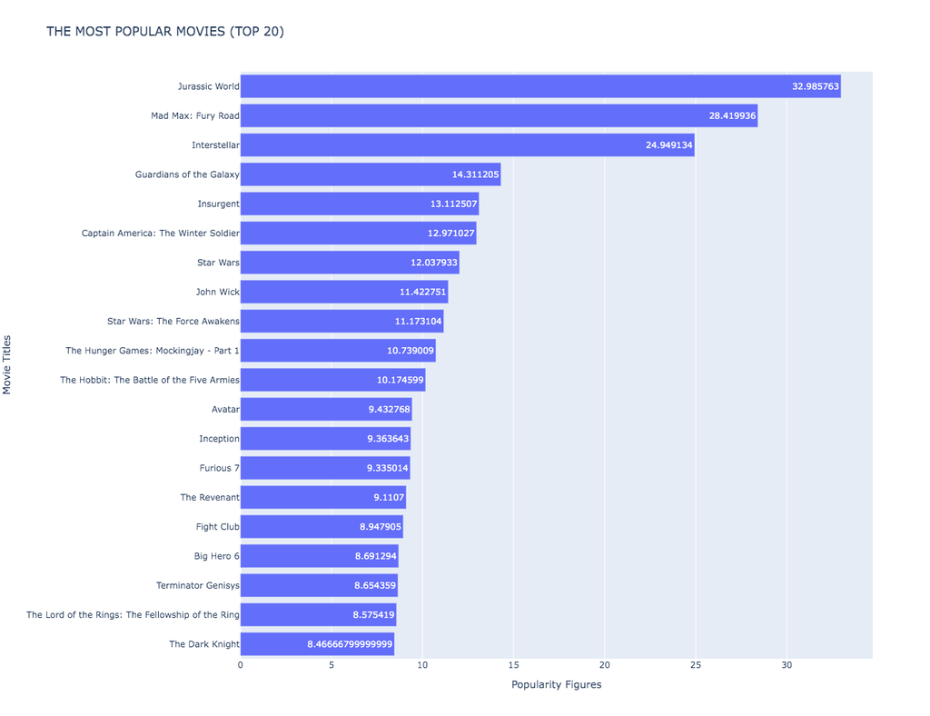

##### OBSERVATION TWO:

> The names of the directors that directed the Top 10 most popular movies are:
> 1. JColin Trevorrow
> 2. George Miller
> 3. Christopher Nolan
> 4. James Gunn
> 5. Robert Schwentke
> 6. Joe Russo|Anthony Russo
> 7. George Lucas
> 8. Chad Stahelski|David Leitch
> 9. J.J. Abrams
> 10. Francis Lawrence

> **Christopher Nolan** & **Peter Jackson** are the only directors that directed more than one movie on the list of the Top 20 most popular movies. This provides an indication on their quality as one of the best directors to have ever graced the movie scene.

##### OBSERVATION THREE:

> **Steven Spielberg**, **Clint Eastwood**, & **Ridley Scott** have directed the most movies in the period under review. See image below:

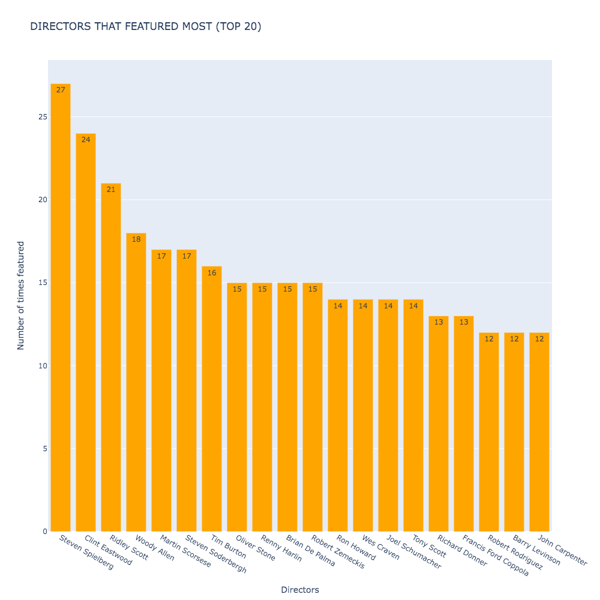

> On further review outside the dataset, we see that the age and longevity of **Steven Spielberg**, **Clint Eastwood**, & **Ridley Scott** have played a role in volume of movies they have directed.

> [Steven Spielberg](https://en.wikipedia.org/wiki/Steven_Spielberg) is **75 yrs old** and active since **1959**.

> [Clint Eastwood](https://en.wikipedia.org/wiki/Clint_Eastwood) is **91 yrs old** and active since **1963**.

> [Ridley Scott](https://en.wikipedia.org/wiki/Ridley_Scott) is **84 yrs old** and active since **1962**.

> Despite having more than one movie in the Top 20 most popular movies, **Christopher Nolan**, & **Peter Jackson** do not appear on the Top 20 list of directors to have directed the most movies in the period under review.

> None of the movies of the directors that featured most in the dataset made the top 20 most popular movies.

##### OBSERVATION FOUR:

> The Top 10 movies with most revenue are:
> 1. Avatar
> 2. Star Wars: The Force Awakens
> 3. Titanic
> 4. The Avengers
> 5. Jurassic World
> 6. Furious 7
> 7. Avengers: Age of Ultron
> 8. Harry Potter and the Deathly Hallows: Part 2
> 9. Frozen
> 10. Iron Man 3

> **Avatar** outstandingly performed better than every other movie in terms of revenue generated. See image below:

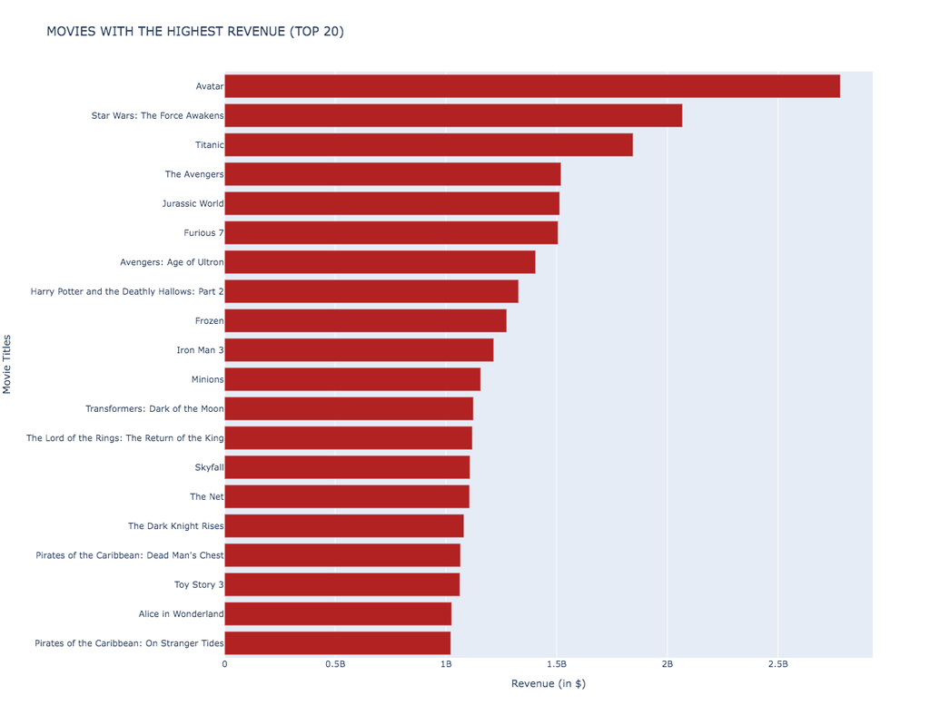

> Also, two **(Avatar & Titanic)** of the top three movies in this category were directed by the same director **(James Cameron)**

##### OBSERVATION FIVE:

> The Top 10 movies with most profit are:
> 1. Avatar
> 2. Star Wars: The Force Awakens
> 3. Titanic
> 4. Jurassic World
> 5. Furious 7
> 6. The Avengers
> 7. Harry Potter and the Deathly Hallows: Part 2
> 8. Avengers: Age of Ultron
> 9. Frozen
> 10. The Net

> The list of movies with the most revenue is almost identical to the list of movies with the most profit. See image below:

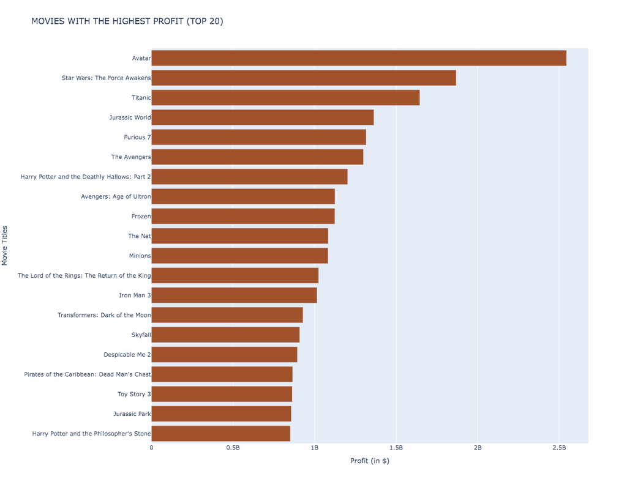

> There were instances of movies that made the list of most revenue but didn't make the list of most profit and vise versa.

> From the above point, we can recognise that even though a few movies made higher revenues than others, it doesn't translate to more profitability.

##### OBSERVATIONS SIX:

> There was a clear trend of increased volume of movie produced as the decades go by.

> 2011 stands high as the peak period for movie production. It's well higher than the mean and median number of movies produced per year.

> See image below:

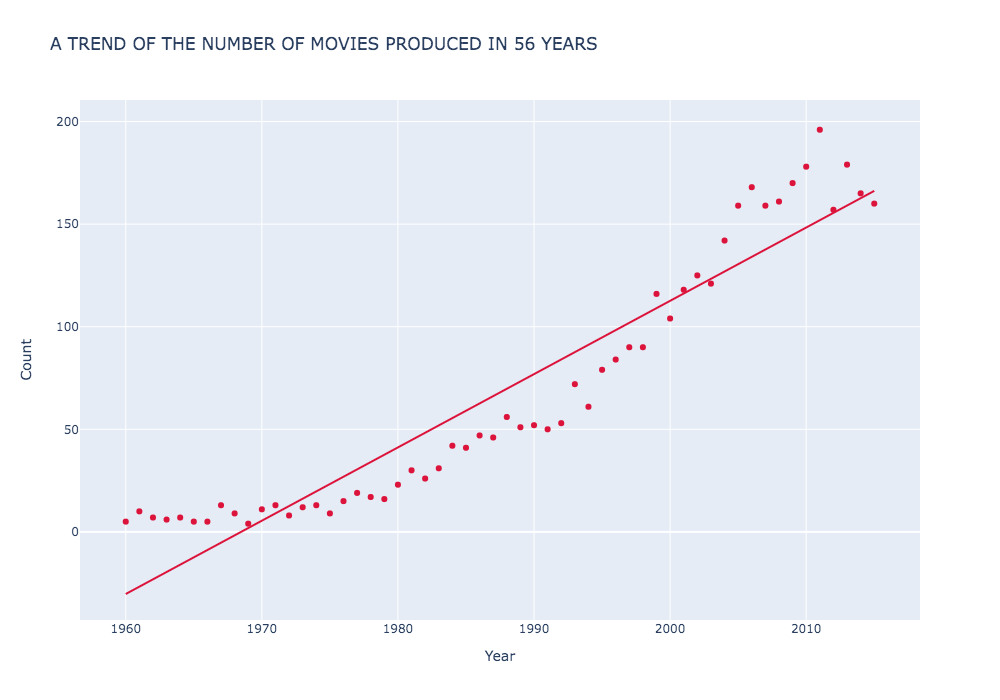

##### OBSERVATION SEVEN:

> We see that the average runtime for the highly rated movies is **39.15 minutes** longer than the average runtime for the lowly rated movies.

> This suggests that the length of movie does not necessarily influence how the audience rates a movie.

##### OBSERVATION EIGHT:

> We see that the average runtime for the highly popular movies is **37.2 minutes** longer than the average runtime for the lowly popular movies.

> This suggests that the length of movie does not necessarily influence the popularity of a movie.

## Limitations:

> The analysis carried out here is not exhaustive. A few limitations exist within this analysis and there are further questions that can be asked for further exploration.

> An example of the few limitations is the fact that I limited top performance of certain variables to a list of Top 20 or Top 10. This might not tell the full story of what it is really going on. Also, during the cleaning of the orginal dataset, I had to drop up to 50% of the rows because they had zero values in the 'budget' & 'revenue' columns. This action might have affected other variables like 'director', 'original_title', & 'release_year'

> Despite the limitations, further questions that can be asked for further exploration are:

> What genre of movies are the most popular?

> What genre of movies are highly rated?

> Are the quality of movies produced getting better as the years go by?

> Which year did movie producers enjoy the most profit?

> Is there a link between a movie runtime & the revenue made from the movie?

#### References

> [Plotly Visualizations](https://plotly.com/python/)

> [Stack Overflow](https://stackoverflow.com/)

> [Code Grepper](https://www.codegrepper.com/code-examples/python/find+difference+between+two+dataframes+pandas)

> [W3resource](https://www.w3resource.com/pandas/dataframe/dataframe-equals.php)

> [Kaggle](https://www.kaggle.com/code/deepak525/investigate-tmdb-movie-dataset/notebook)